# Weekly Assignment 2

Sean Leggett - BDA201 February 6, 2020

## Question 1

Examine the provided csv file and perform basic data inspection.

Answer: No gaps exist in the data. The subjects have been anonymized. Fourteen fields exist. Column titles include some spaces. Last names are duplicated for Jane/John Doe.

## Question 2

What is the datatype of each feature?

Answer:  
* ID - Qualitative/ordinal  
* Last Name - Qualitative/nominal  
* First Name - Qualitative/nominal  
* City - Qualitative/nominal  
* State - Qualitative/nominal  
* Gender - Qualitative/nominal  
* Student Status - Qualitative/nominal  
* Major - Qualitative/nominal  
* Country - Qualitative/nominal  
* Age - Quantitative/interval/continuous  
* SAT - Quantitative/ratio/discrete  
* Average score (grade) - Quantitative/ratio/continuous  
* Height (in) - Quantitative/ratio/continuous  
* Newspaper readership (times/wk) - Quantitative/ration/discrete

## Question 3

Use summary() function to display a summary of the features.

Answer:

```r
scores <- read.csv("Assignment_2_data.csv")
summary(scores)
```

```
     ï..ID         Last.Name    First.Name           City
 Min.   : 1.00   DOE01  : 2   JANE01 : 1   New York    : 2
 1st Qu.: 8.25   DOE02  : 2   JANE02 : 1   Acme        : 1
 Median :15.50   DOE03  : 2   JANE03 : 1   Amsterdam   : 1
 Mean   :15.50   DOE04  : 2   JANE04 : 1   Beijing     : 1
 3rd Qu.:22.75   DOE05  : 2   JANE05 : 1   Buenos Aires: 1
 Max.   :30.00   DOE06  : 2   JANE06 : 1   Caracas     : 1
                 (Other):18   (Other):24   (Other)     :23
        State       Gender         Student.Status      Major
 New York  : 5   Female:15   Graduate     :15     Econ    :10
 Argentina : 1   Male  :15   Undergraduate:15     Math    :10
 Arizona   : 1                                    Politics:10
 Bulgaria  : 1
 California: 1
 Canada    : 1
 (Other)   :20
      Country        Age            SAT       Average.score..grade.
 US       :20   Min.   :18.0   Min.   :1338   Min.   :63.00
 Argentina: 1   1st Qu.:19.0   1st Qu.:1658   1st Qu.:72.00
 Bulgaria : 1   Median :23.0   Median :1817   Median :79.50
 Canada   : 1   Mean   :25.2   Mean   :1849   Mean   :80.37
 China    : 1   3rd Qu.:30.0   3rd Qu.:2032   3rd Qu.:88.00
 Holland  : 1   Max.   :39.0   Max.   :2309   Max.   :96.00
 (Other)  : 5
  Height..in.    Newspaper.readership..times.wk.
 Min.   :59.00   Min.   :3.000
 1st Qu.:63.00   1st Qu.:4.000
 Median :66.50   Median :5.000
 Mean   :66.43   Mean   :4.867
 3rd Qu.:70.75   3rd Qu.:6.000
 Max.   :75.00   Max.   :7.000
```

## Question 4 and Question 5

How many males/females? How many graduate/undergraduate? Plot both using bar plots.

Answer:  
Summary shows us that there are 15 each of males and females. Also, 15 each of graduates and undergraduates.

```r
par(mfrow=c(1,2)) ## draw layout for frames
par(cex.axis=0.75) ## smaller text on x axis to fit
barplot(table(scores$Gender))
barplot(table(scores$Student.Status))
```

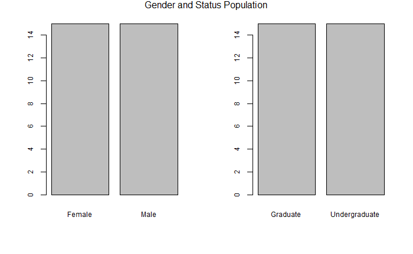

```r
mtext("Gender and Status Population", outer=TRUE,  cex=1, line = -.9)
```

## Question 6

Is the average SAT score same for graduates and undergraduates?

Answer:  
Undergraduates have a slightly higher average(mean) SAT score.1,841.2 for graduates vs 1,856.6 for undergraduates.

```r
grads <- subset(scores, Student.Status == "Graduate")
undergrads <- subset(scores, Student.Status == "Undergraduate")

gradsavg <- mean(grads$SAT)
underavg <- mean(undergrads$SAT)
gradsavg
```

```
[1] 1841.2
```

```r
underavg
```

```
[1] 1856.6
```

## Question 7

Between men or women? Who reads the newspaper more frequently and which group has more variation? (show using box plots)

Answer:  
The women from this sample read more newspapers weekly than men; the men from the sample have a greater variability in number of times per week they read newspapers. The plot below illustrates this finding.

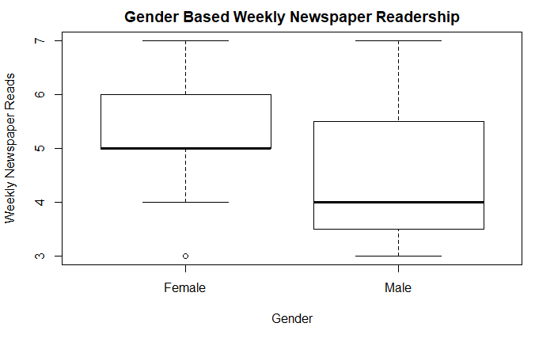

```r
readership <- boxplot(Newspaper.readership..times.wk. ~ Gender, data = scores,
                      main = "Gender Based Weekly Newspaper Readership",
                      xlab = "Gender",
                      ylab = "Weekly Newspaper Reads")
```

## Question 8

For age, Height, and Newspaper readership, calculate the following using R: a. Measures of location such as mean, median, and mode (where applicable). b. Measures of variation such as variance, standard deviation and IQR

Answer:  
The code below provides the measures requested:

Part A: Mean and Median  
Calculated and grouped into dataframe for ease of presentation.

```r
agemean <- mean(scores$Age)
heightmean <- mean(scores$Height..in.)
readershipmean <- mean(scores$Newspaper.readership..times.wk.)
agemedian <- median(scores$Age)
heightmedian <- median(scores$Height..in.)
readershipmedian <- median(scores$Newspaper.readership..times.wk.)

dfLocations <- data.frame("Variable" = c("Age", "Height", "Readership"), "Mean" = c(agemean, heightmean, readershipmean), "Median" = c(agemedian, heightmedian, readershipmedian))

dfLocations
```

| Variable | Mean | Median |
| --- | --- | --- |
| Age | 25.200000 | 23.0 |
| Height | 66.433333 | 66.5 |
| Readership | 4.866667 | 5.0 |

Part A: Mode

There is no function for mode (statistical mode) in base R. With a small dataset such as this, it is reasonable to simply sort and count.

For Age we have a dual mode of 18 and 19 each with 5 observations. For Height we have a mode of 68 inches with 4 observations. For Readership we have a mode of 5 with 9 observations.

There are packages to expand statistical functions and some include mode calculations. For larger datasets these would be hepful. Or else a programmatical approach leveraging some sort of count and max functions.

```r
agemodetest <- sort(scores$Age)
agemodetest
```

```
 [1] 18 18 18 18 18 19 19 19 19 19 20 20 21 21 21 25 25 26 28 30 30 30 30 31 33 33 33 37 38
[30] 39
```

```r
heightmodetest <- sort(scores$Height..in.)
heightmodetest
```

```
 [1] 59 59 60 61 62 62 62 63 63 63 64 64 64 65 66 67 67 68 68 68 68 70 71 71 71 72 73 73 74
[30] 75
```

```r
readershipmodetest <- sort(scores$Newspaper.readership..times.wk.)
readershipmodetest
```

```
 [1] 3 3 3 3 3 3 4 4 4 4 4 5 5 5 5 5 5 5 5 5 6 6 6 6 6 6 6 7 7 7
```

Part B: Measures of Variation  
Calculated and grouped into dataframe for ease of presentation.

```r
agevariance <- var(scores$Age)
heightvariance <- var(scores$Height..in.)
readershipvariance <- var(scores$Newspaper.readership..times.wk.)
sdage <- sd(scores$Age)
sdheight <- sd(scores$Height..in.)
sdreadership <- sd(scores$Newspaper.readership..times.wk.)
ageIQR <- IQR(scores$Age)
heightIQR <- IQR(scores$Height..in.)
readershipIQR <- IQR(scores$Newspaper.readership..times.wk.)

dfvariation <- data.frame("Variable" = c("Age", "Height", "Readership"), "Variance" = c(agevariance, heightvariance, readershipvariance), "Standard Deviation" = c(sdage, sdheight, sdreadership), "IQR" = c(ageIQR, heightIQR, readershipIQR))

dfvariation
```

| Variable | Variance | Standard.Deviation | IQR |
| --- | --- | --- | --- |
| Age | 47.200000 | 6.870226 | 11.00 |
| Height | 21.702299 | 4.658573 | 7.75 |
| Readership | 1.636782 | 1.279368 | 2.00 |

Reference Material:  
1. Course Content  
2. Sams Teach Yourself R in 24 Hours, Andy Nicholls, Richard Pugh, Aimee Gott. Sams, 2016.